# Student Performance Evaluation Analysis

### Subject Anxiety on Gender

Which gender has more anxiety when it comes to math, male or female?

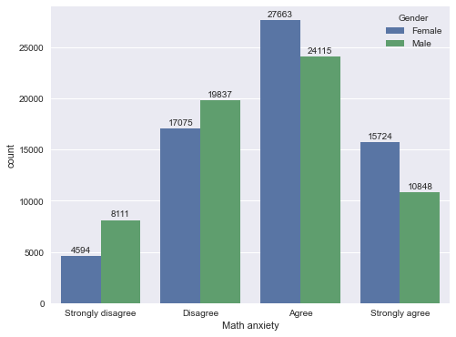

```python
fig, ax = plt.subplots(figsize=(7, 6))
g=sb.countplot(data=pisa_df, x='math_anxiety', hue='gender')
g.set(xlabel='Math anxiety')
ax.bar_label(ax.containers[0], label_type='edge', padding=2) # Adding annotation
ax.bar_label(ax.containers[1], label_type='edge', padding=2) # Adding annotation
plt.legend(title='Gender');
```

### Talk about some of the relationships you observed in this part of the investigation. How did the feature(s) of interest vary with other features in the dataset?

- Student with the highest score always has access to a study place, a computer, and the internet, i.e., there is a relationship between a student's examination score and possession.
- Primary education contributes excellently to the performance of students in their academics, i.e., primary education is related to high academic performance.
- The age at which students start their primary education has a great influence on their academic performance, i.e., primary education age is related to student academic performance.
- Parental degree is related to student academic performance.
- Parental occupation status has a great influence on the performance of students in their academics, i.e., students working full-time perform excellently in their academics.

### Did you observe any interesting relationships between the other features (not the main feature(s) of interest)?

- Math anxiety is related to a student's math score.
- Most students in various countries appear to always have a high exam score because a large number of students have all of the basic amenities such as a study room, computer, internet, and textbooks.
- It is quite surprising that the behaviour of a student with the highest score in mathematics always falls between the range of 0–1.
- Student scores on all rated teachers' behaviour are quite similar.

## Multivariate Exploration

In this section, an in-depth variable association will be done to see more interesting relationship.

### Gender, Score and Country

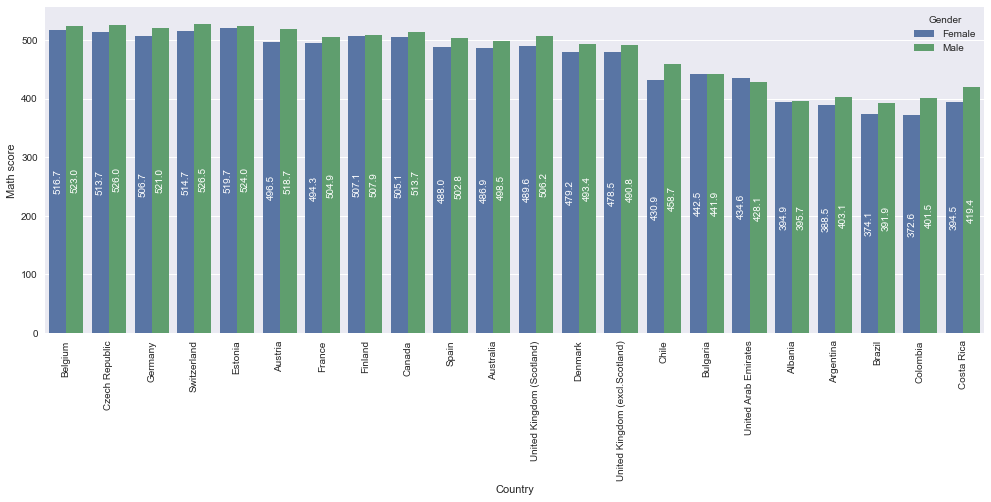

```python
fig, ax = plt.subplots(figsize=(15, 6))
g = sb.barplot(data=pisa_df, y='math_score', x='country', errwidth=0, hue='gender', order=order)
ax.bar_label(ax.containers[0], rotation=90, fmt='%.1f', label_type='center', color='white')
ax.bar_label(ax.containers[1], rotation=90, fmt='%.1f', label_type='center', color='white')
g.set(xlabel="Country", ylabel="Math score")
plt.xticks(rotation=90)
plt.legend(title='Gender');
```

In most countries, male students perform higher than females in mathematics.

### Primary Education and Possession of study place effect on Student Performance

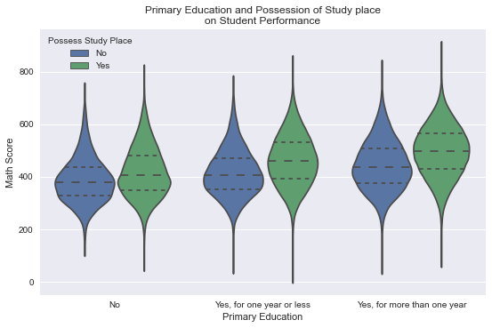

```python
g = sb.violinplot(data=pisa_df, x='pri_sch', y='math_score', hue='possess_study_place', inner='quartile')
g.set(xlabel="Primary Education", ylabel="Math Score", title="Primary Education and Possession of Study place\non Student Performance")
plt.legend(loc=2, title="Possess Study Place");
```

The effect of primary education on math scores varies based on whether students possess a study place. Most students with the best performance in mathematics have a place of study.

### Student age in Primary Education effect on their reading performance

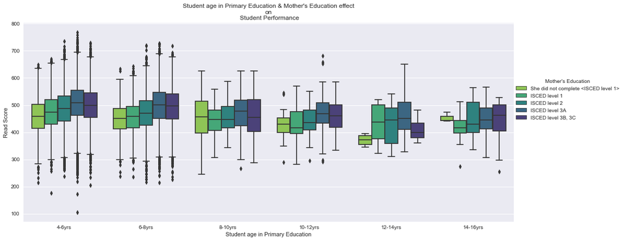

```python
mathscore_above_25_percent['age_label'] = pd.cut(mathscore_above_25_percent['age_at_pri_sch'],
                                                bins=[4, 6, 8, 10, 12, 14, 16],
                                                labels=["4-6yrs", "6-8yrs", '8-10yrs', "10-12yrs", '12-14yrs', '14-16yrs'])

fig, ax = plt.subplots(figsize=(15, 7))
g = sb.boxplot(data=mathscore_above_25_percent, x='age_label', y='read_score', hue='mother_sch_lvl',
                     palette='viridis_r', ax=ax)
g.set(xlabel='Student age in Primary Education',
            ylabel="Read Score", title="Student age in Primary Education & Mother's Education effect\non\n Student Performance")
plt.legend(loc=(1, 0.5), title="Mother's Education");
```

### Student Interest effect on their Performance in Examination

How does the interest of students affect their examination scores? Is it gender specific?

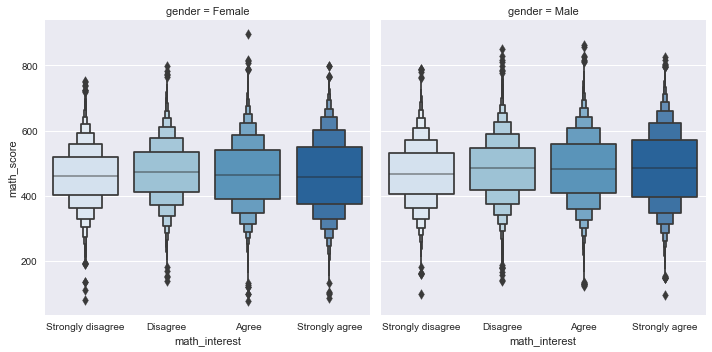

```python
g = sb.FacetGrid(data=pisa_df, col='gender', aspect=1, height=5)
g.map(sb.boxenplot, 'math_interest', 'math_score', palette='Blues');
```

### Relationships between all numerical features

Is there a relationship between students' examination scores in different subjects? Does the teacher's support have any relationship with the student's examination score?

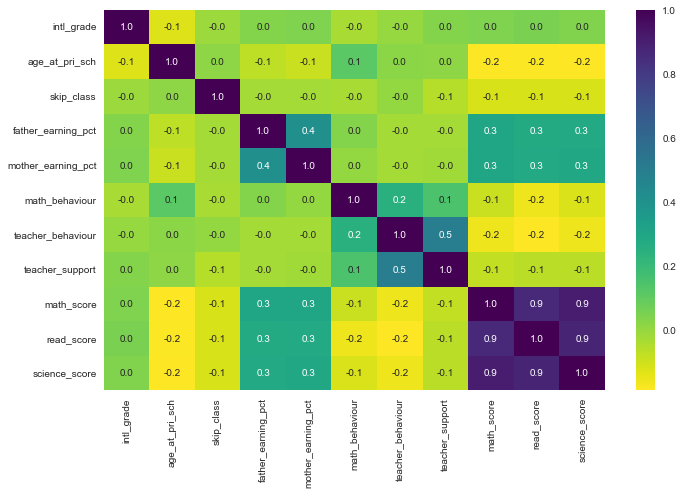

```python
fig, ax = plt.subplots(figsize=(10, 7))
sb.heatmap(pisa_df.corr(), cmap='viridis_r', annot=True, fmt='.1f', ax=ax);
```

### Parent Earning Effect on Students score

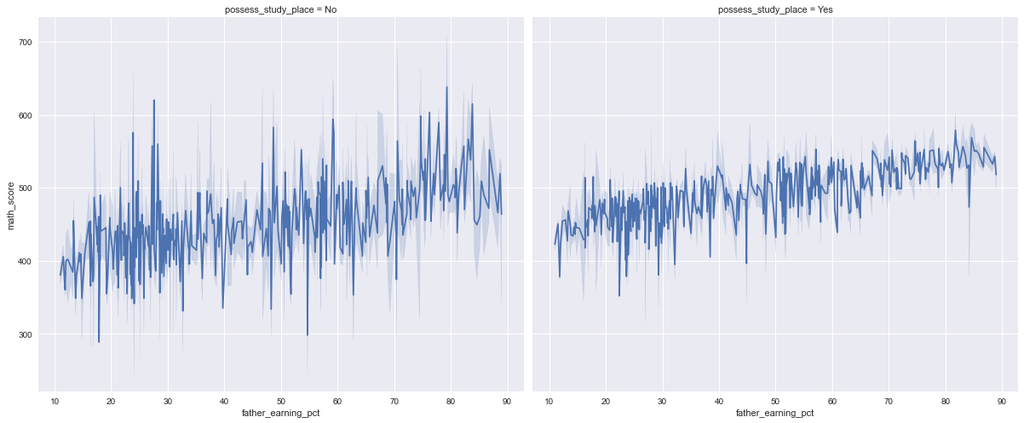

```python
g = sb.FacetGrid(data=pisa_df, col='possess_study_place', aspect=1.2, height=7)
g.map(sb.lineplot, 'father_earning_pct', 'math_score');
```

There is an upward trend between parent earning and the performance of students in examinations. The level of consistency in the upward trend in the scores of students that possess a study place is more smooth as compared to those that have no study place, i.e., there is a consistent increase in the scores of students based on the earnings of their parents.

### Talk about some of the relationships you observed in this part of the investigation. Were there features that strengthened each other in terms of looking at your feature(s) of interest?

- In most countries, male students perform well in mathematics.
- There is a relationship between the years students spent in primary education and their performance in higher education.
- Students with highly educated parents that enrol in primary education early perform well in their higher education as compared to others.
- There is a relationship between the student's study interest and the examination score.
- The parent's earnings have a slight relationship with the student's examination score.

## Conclusions

When a student's basic school foundation is strong, their performance will always be exceptional. This study has contributed to the confirmation that children perform better academically the sooner they begin their schooling. Because most values that will contribute to knowledge demand money, parent education and occupation has a significant impact on their children's academic and vocational performance. As is widely known, literate parents will approach schooling very differently than uneducated parents. Most students who have a reading room, a book to read, a computer to conduct research on, and access to the internet to browse do well in school and achieve higher exam scores, but this is quite different for general knowledge (international examination) because every student has a different area of strength and weakness.